# DataScienceProject2

## Clustering

```r
BigDataset_scaled <- BigDatasetFinalnum %>%
  select(GoalsFor, GoalsAgainst, Wins, Losses, Points) %>%
  scale

kmeans_results <- BigDataset_scaled %>%
  kmeans(centers = 2) # centers determine the number of clusters

#
BigDataset_kmeans <- BigDatasetFinalnum %>%
  mutate(cluster = as.factor(kmeans_results$cluster))

# Look at 10 random values
sample_n(BigDataset_kmeans, 10)
```

```
## # A tibble: 10 × 9
##     Rank  Wins Losses GoalsFor GoalsAgainst Games Points Draws cluster
##    <int> <int>  <int>    <int>        <int> <int>  <int> <int> <fct>
##  1    19     4     24       40           94    38     22    10 2
##  2     5    15      9       58           44    34     55    10 1
##  3     8    13     15       61           64    34     45     6 2
##  4    15     8     12       45           61    38     42    18 2
##  5    16     7     17       35           60    38     35    14 2
##  6    10    13     16       47           51    38     48     9 2
##  7     2    20      5       72           38    34     69     9 1
##  8    17     8     18       36           57    34     32     8 2
##  9     6    16     10       48           37    38     60    12 1
## 10     9    10     11       38           42    34     43    13 2
```

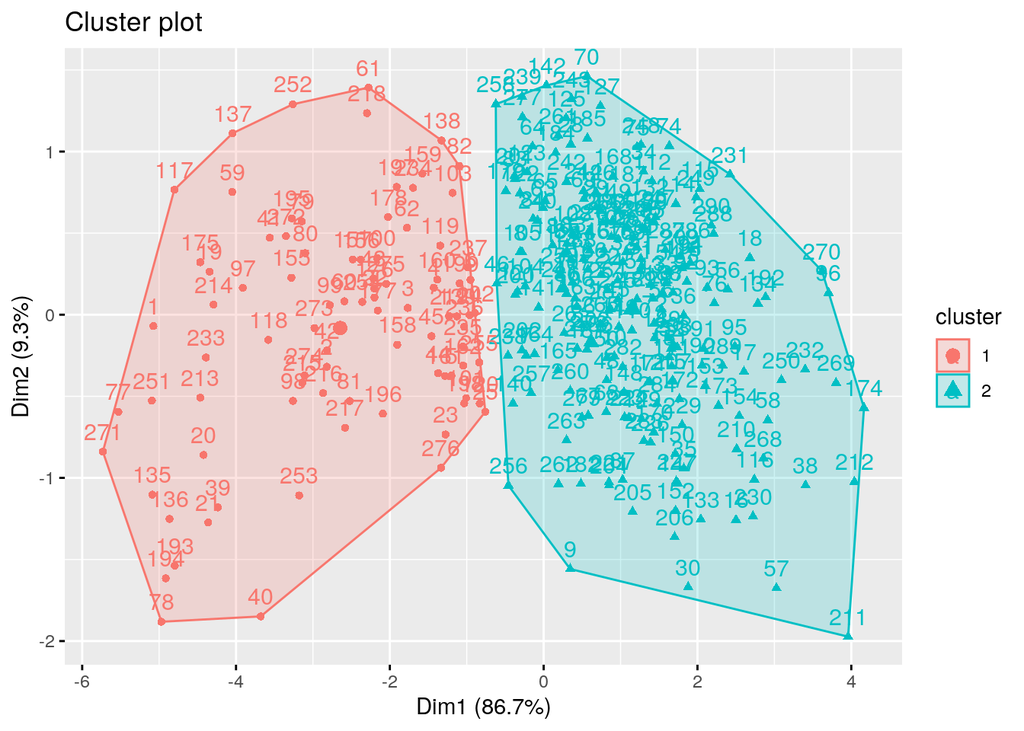

```r
# Finds the optimal number of clusters
fviz_cluster(kmeans_results, data = BigDataset_scaled)
```

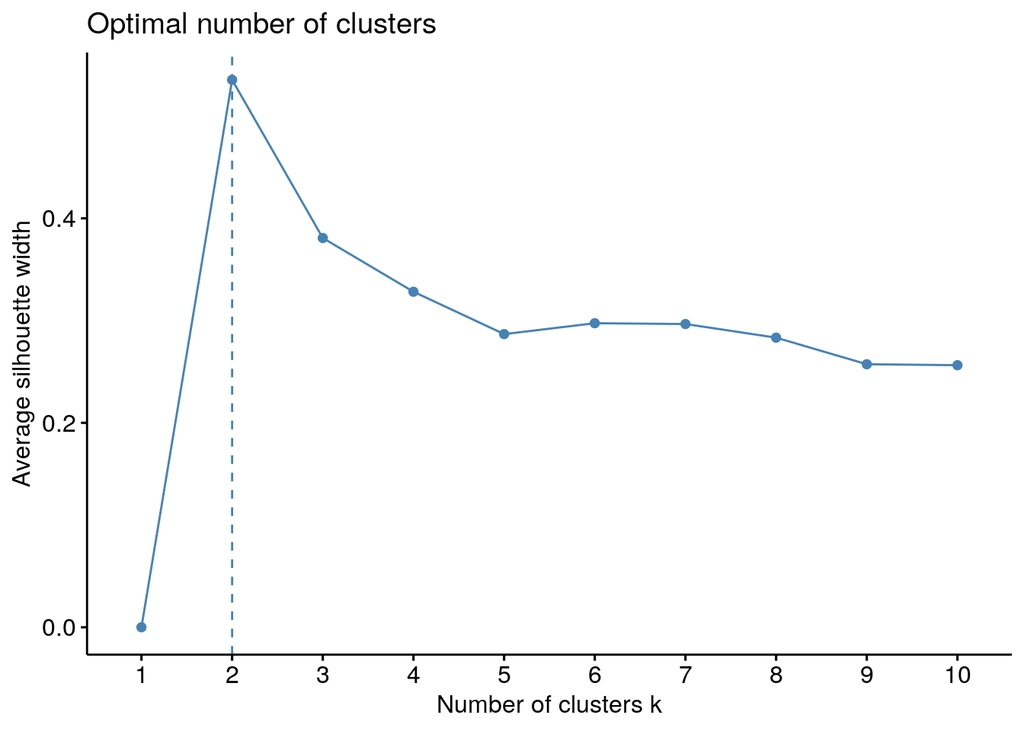

```r
# obtains silhouette of the kmeans cluster
fviz_nbclust(BigDataset_scaled, kmeans, method = "silhouette")
```

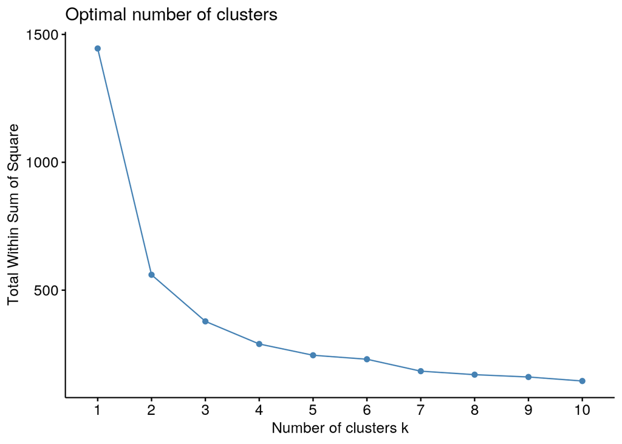

```r
# visualizes kmeans cluster
fviz_nbclust(BigDataset_scaled, kmeans, method = "wss")
```

```r
# Observe the results of kmeans clustering
kmeans_results
```

```
## K-means clustering with 2 clusters of sizes 88, 202
##
## Cluster means:
##     GoalsFor GoalsAgainst       Wins    Losses     Points
## 1  1.1675342    -1.006520  1.2629205 -1.186236  1.2751082
## 2 -0.5086288     0.438484 -0.5501832  0.516776 -0.5554927
##
## Clustering vector:
##   [1] 1 1 1 1 1 1 2 2 2 2 2 2 2 2 2 2 2 2 1 1 1 1 1 1 1 2 2 2 2 2 2 2 2 2 2 2 2
##  [38] 2 1 1 1 1 1 1 1 2 2 2 2 2 2 2 2 2 2 2 2 2 1 1 1 1 2 2 2 2 2 2 2 2 2 2 2 2
##  [75] 2 2 1 1 1 1 1 1 2 2 2 2 2 2 2 2 2 2 2 2 2 2 1 1 1 1 1 1 1 2 2 2 2 2 2 2 2
## [112] 2 2 2 2 2 1 1 1 1 2 2 2 2 2 2 2 2 2 2 2 2 2 2 1 1 1 1 1 2 2 2 2 2 2 2 2 2
## [149] 2 2 2 2 2 2 1 1 1 1 1 1 1 1 2 2 2 2 2 2 2 2 2 2 2 2 1 1 1 1 2 2 2 2 2 2 2
## [186] 2 2 2 2 2 2 2 1 1 1 1 1 1 1 2 2 2 2 2 2 2 2 2 2 2 2 2 1 1 1 1 1 1 1 2 2 2
## [223] 2 2 2 2 2 2 2 2 2 2 1 1 1 1 1 2 2 2 2 2 2 2 2 2 2 2 2 2 1 1 1 1 1 2 2 2 2
## [260] 2 2 2 2 2 2 2 2 2 2 2 1 1 1 1 1 1 2 2 2 2 2 2 2 2 2 2 2 2 2 2
##
## Within cluster sum of squares by cluster:
## [1] 226.7320 333.3754
##  (between_SS / total_SS =  61.2 %)
##
## Available components:
##
## [1] "cluster"      "centers"      "totss"        "withinss"     "tot.withinss"
## [6] "betweenss"    "size"         "iter"         "ifault"
```

**After using kmeans to cluster our data, we found that it was optimal to use 2 clusters because of the elbow test and the silhouette test. Cluster 1 represents the team observations with more wins, points, and goals while Cluster 2 represents observations with more losses, goals conceded, and least points. The observation in the middle represents West Bromwich Albion in the 2013-2014 season where they had 36 points, 43 goals, and 7 wins. According to the kmeans results, Cluster 1 had a GoalsFor statistic of 1.168 while Cluster 2 had one of -0.51. For Goals Conceded, Cluster 2 had a higher value compared to Cluster 1 (0.438 vs -1.00). For team wins, Cluster 1 had a higher value compared to Cluster 2 (1.26 vs -0.551). For losses, Cluster 1 has a lower value compared to Cluster 2 (-1.19 vs 0.52). Lastly, for Points, Cluster 1 had a higher value than Cluster 2 (1.28 vs -0.56).**